# a3_task3_taylor_lockmann

Taylor Lockmann

11/4/2020

### Read in urchins data

```r
urchins <- read.csv(here("data", "urchins.csv"))
```

### Section 1: Size comparisons, purple and red urchins

#### i. Exploratory data visualization: Compare the distribution of sizes between purple and red urchins using a histogram and a boxplot.

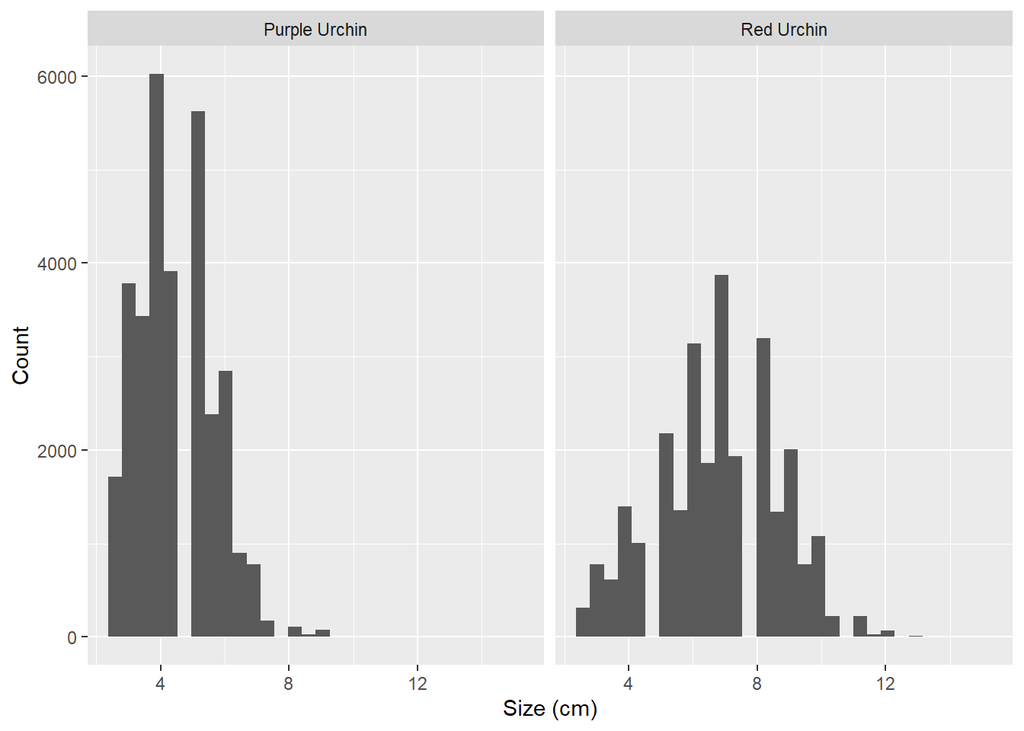

```r
ggplot(data = urchins, aes(x = SIZE))+ #Read in the data, specify the x-axis variable
  geom_histogram()+ #Start with a simple histogram
  facet_wrap(~COMMON_NAME)+ #Facets according to each type of urchin
  labs(
    x = "Size (cm)",
    y = "Count"
  )
```

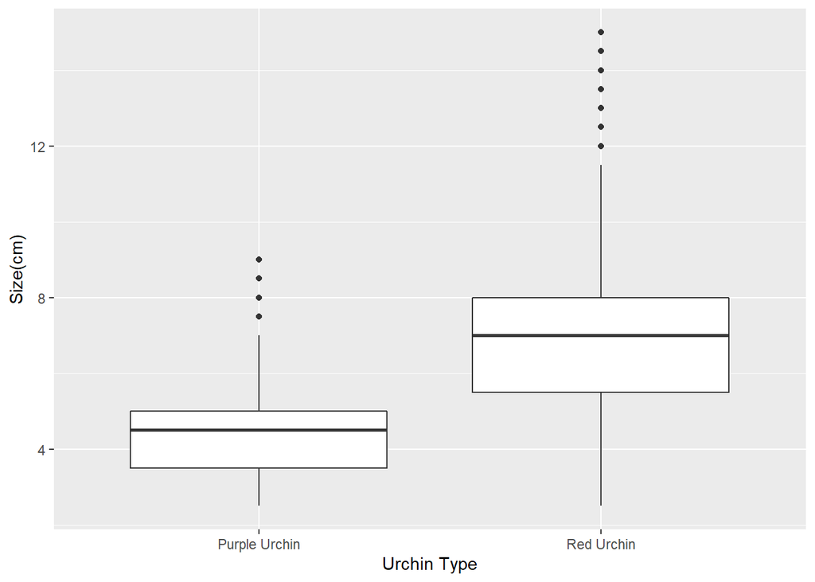

```r
ggplot(data = urchins, aes(x = COMMON_NAME, y = SIZE))+ #Read in the data, specify the x and y-axis variables
  geom_boxplot()+ # Use a boxplot for exploratory visualization this time
  labs(
    x = "Urchin Type",
    y = "Size(cm)"
  )
```

#### ii. Descriptive statistics table: Create a summary table that contains the following statistics for purple and red urchins (still ignoring site as a variable): mean, median, standard deviation, and sample size. You may want to use kableExtra to help make it a bit nicer for your knitted document (hint: group_by() %>% summarize(mean, median, sd, n))

```r
urchin_stats <- urchins %>% # Start with my urchins data
  group_by(COMMON_NAME) %>% # Group according to common name/urchin type
  summarize(Mean = mean(SIZE),
            Median = median(SIZE),
            SD = sd(SIZE),
            N = n()) # Specify what I want in my summary table

kbl(urchin_stats, caption = "Urchins Statistics") %>%
  kable_styling(bootstrap_options = "striped",
                full_width = F)
```

Urchins Statistics

| COMMON_NAME | Mean | Median | SD | N |
| --- | --- | --- | --- | --- |
| Purple Urchin | 4.469797 | 4.5 | 1.175264 | 31805 |
| Red Urchin | 6.776489 | 7.0 | 1.891343 | 27408 |

### Section 2. Explore purple urchin counts by site and year

#### i. In a piped sequence, create a stored subset of the urchins data called purple_urchins in which you:

- Filter to only include observations for purple urchins
- Convert the date to class “Date”
- Create a new column that only contains the year
- Create a new column called site_full that contains the full name (not abbreviation) for each of the five sites: NAPL = Naples Reef, AQUE = Arroyo Quemado Reef, CARP = Carpinteria Reef, MOHK = Mohawk Reef, IVEE = Isla Vista Reef. Hint: case_when()

```r
purple_urchins <- urchins %>% # Start with urchins data
  filter(COMMON_NAME == "Purple Urchin") %>% # Filter to only purple urchins
  mutate(date_new = mdy(DATE)) %>% #Convert DATE column to class "Date"
  mutate(Year = year(date_new)) %>% # Create a new column of only the date
  mutate(site_full = case_when( #Add a new column "site_full", which contains...
    SITE == "NAPL" ~ "Naples Reef", #if site is NAPL, change to Naple Reef
    SITE == "AQUE" ~ "Arroyo Quemado Reef", # change AQUE to Arroyo Quemado Reef
    SITE == "CARP" ~ "Carpinteria Reef", # change CARP to Carpinteria Reef
    SITE == "MOHK" ~ "Mohawk Reef", # change MOHK to Mohawk Reef
    SITE == "IVEE" ~ "Isla Vista Reef"))# change IVEE to Isla Vista Reef
```

#### ii. Make a summary table containing the total number of purple urchins observed by site and year, starting from purple_urchins you created above and using the count() function to find counts of observations by group. You do not need to finalize this table (you’ll just use the output in a plot in the next step)

```r
# Summary table
purple_urchins_site_summary <- purple_urchins %>%
  count(site_full, Year)
```

#### iii. Make an exploratory graph of counts of purple urchins recorded at each site over time for the years included in the study. It does not need to be finalized.

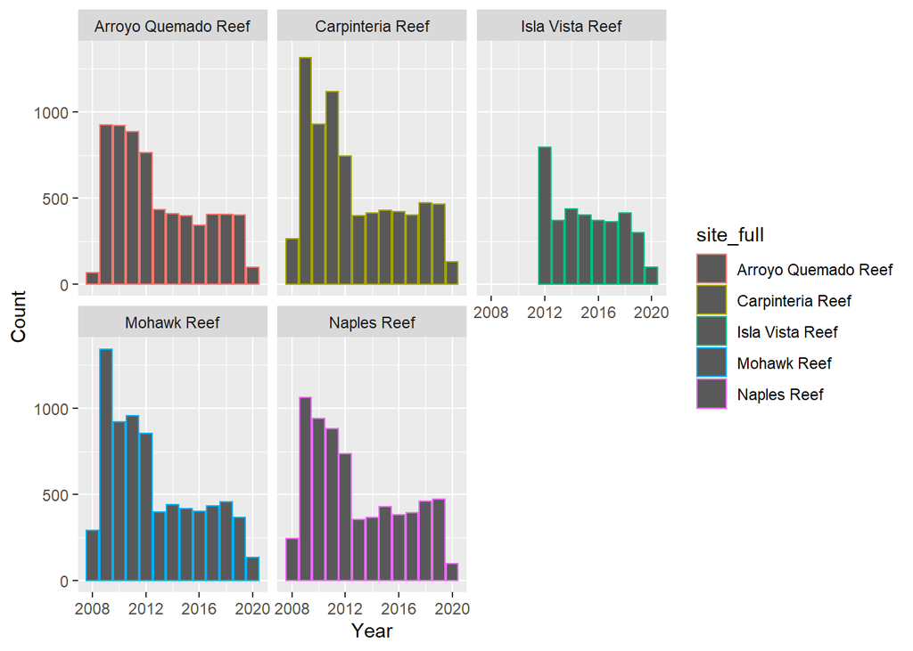

```r
## Graph from summary table data
ggplot(data = purple_urchins_site_summary, aes(x = Year, y = n, color = site_full))+
  geom_col(bins = 30)+
  facet_wrap(~site_full)+
  labs(
    x = "Year",
    y = "Count",
    site_full = "Site Name")
```

#### iv. Save & knit your .Rmd for this task, then commit & push to GitHub for safekeeping. You will upload your .Rmd and HTML for Task 3 to GauchoSpace.

### END TASK 3